# Supplement S5: Scaling survival and comparing survival across taxonomic units based on gestation duration

# 1 Preamble

This is an Electronic Supplement to the manuscript Marques et al. “Quantifying Deepwater Horizon oil spill induced injury on pelagic cetaceans” published in Marine Ecology Progress Series.

There are 8 Electronic Supplements to the paper. The master file containing links to all the other 7 additional Electronic Supplements related to this paper is Supplement_S1.

You might be reading this file as a pdf or as an html. If you reading this file as a pdf distributed as an Electronic Supplement to the MEPS paper, the links will not work. The links on this file only work if:

1. you are using the html version of it, available via the https://github.com/TiagoAMarques/CARMMHApapersSI, or
2. if you compiled it yourself as html and you have all the 8 html files in the same folder.

## 1.1 Version history

This section details the version history for static pdf files submitted as Electronic Supplement pdfs:

- 1.0 [12 Aug 2022] Version included as a pdf Electronic Supplement in the MEPS original submission
- 2.0 [10 Feb 2023] Version included as a pdf Electronic Supplement in the MEPS re-submission after 1st round of reviewer’s comments
- 3.0 [26 May 2023] Version with all file names renamed to match requirements by editorial team at MEPS

Given MEPS’s Supplements correspond to static files, readers might want to check if there are any new file versions or added materials at the project github repository: The source .Rmd files are provided in the github repository:

In this document we look at the age specific survival used for each taxonomic unit scaled by the corresponding gestation duration, as described in the manuscript.

# 2 Reading relevant info

We read in the species details, set the species which we want results for, and then filter the input data for those species only.

We also read in *Tursiops truncatus* bottlenose dolphin (BND) Siler model posterior values. These can then be used to estimate:

1. survival conditional on age, and
2. survivorship functions for this species.

The corresponding values for all other species/stocks are obtained by scaling the *Tursiops truncatus* values by gestation duration.

# 3 *Tursiops truncatus*

Here we represent the relevant functions and the associated variability is also illustrated.

## 3.1 Survivorship function

We plot the age specific survival aka survivorship function for BND. See Schwacke et al. (2017) and the corresponding online material for details on how this was derived based on a Siler model fitted to strandings data.

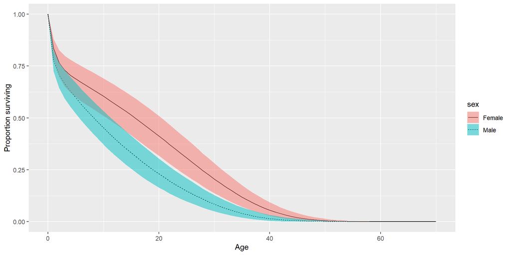

## 3.2 Age specific Survival

We plot age specific survival

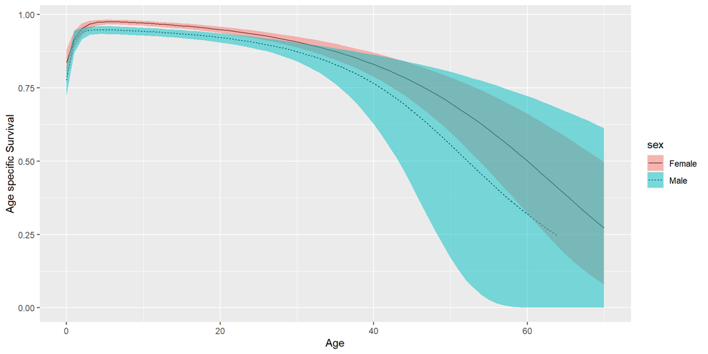

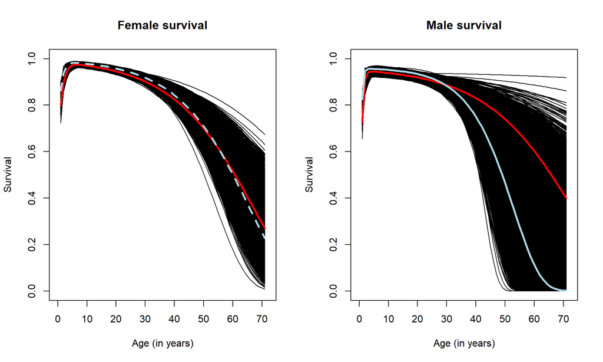

# 4 Comparing all species

The scaling is done by gestation duration, so we look at the gestation duration considered for each of the species. The rationale for each species gestation duration used is provided on a separate document included as a separate file: Supplement_S4.

The range in gestation duration is shown below (note the x axis is just an index, species are shown from left to right in the increasing order of their gestation duration).

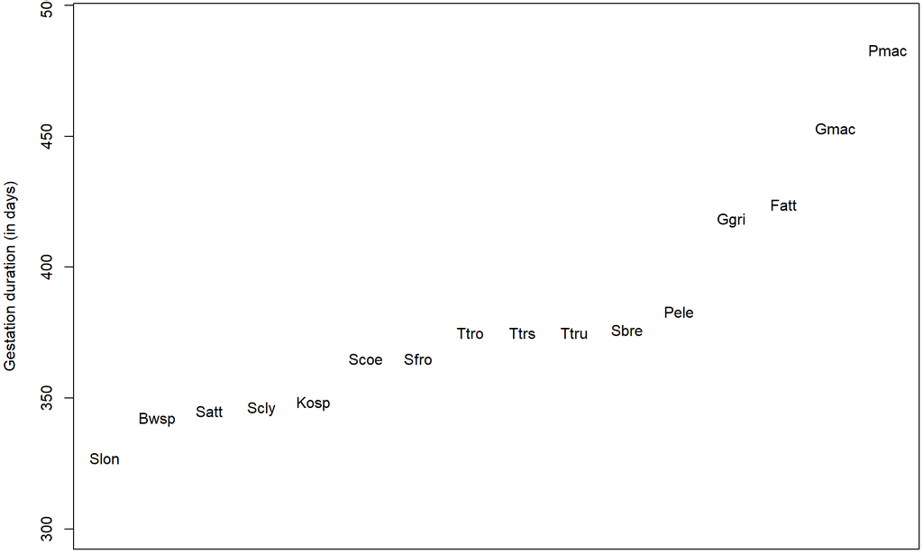

## 4.1 Survivorship function

We present the scaled survivorship by taxonomic unit and sex below. For reference Barataria Bay bottlenose dolphins shown in green, sperm whale in blue and spinner dolphin in light blue

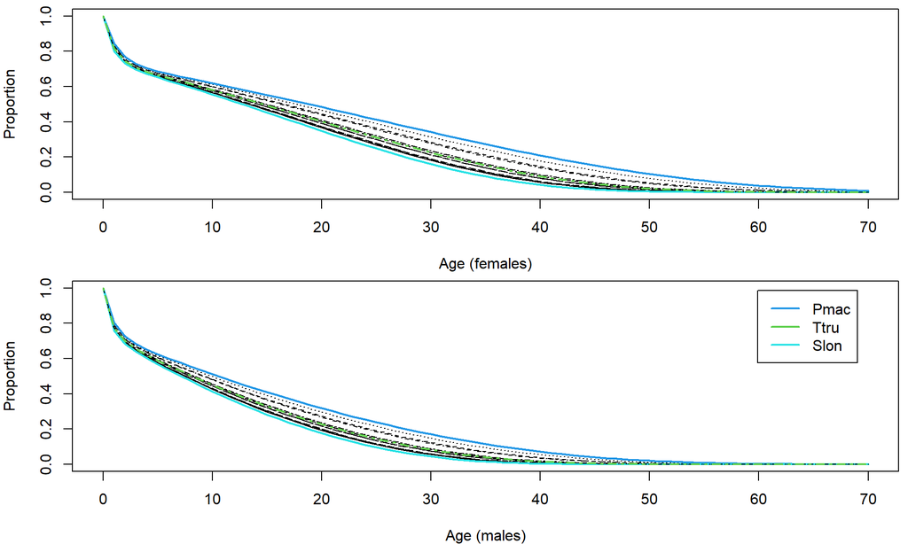

## 4.2 Age specific survival

We present the scalled age specific survival by function below. For reference BB BND shown in green, sperm whale in blue and spinner dolphin in light blue

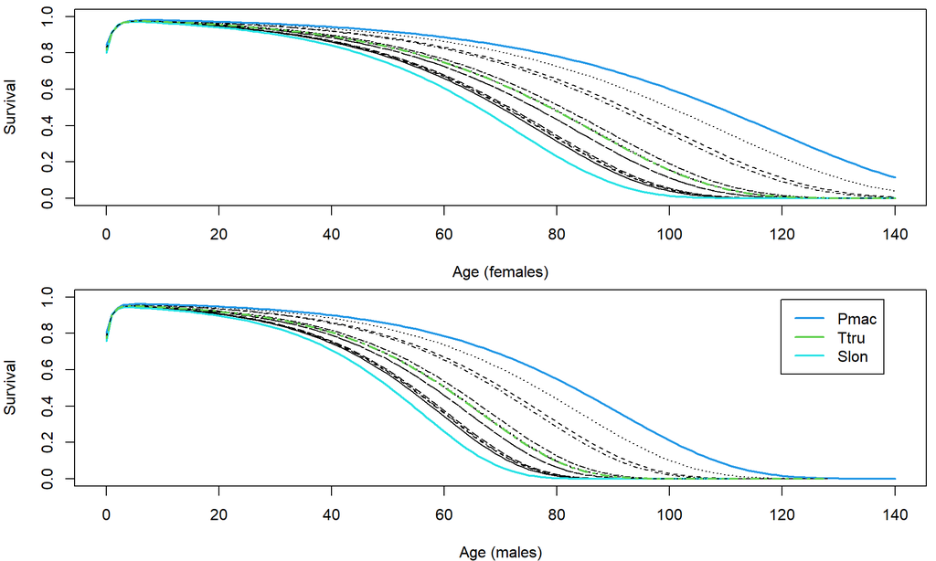

# 5 References

Schwacke, L.H., L. Thomas, R.S. Wells, W.E. McFee, A.A. Hahn, K.D. Mullin, E.S. Zolman, B.M. Quigley, T.K. Rowles and J.H. Schwacke. 2017. An age-, sex- and class-structured population model for estimating nearshore common bottlenose dolphin injury following the Deepwater Horizon oil spill. *Endangered Species Research* **33**: 265-279. DOI: 10.3354/esr00777.